# Project 4

Meaghan Burke

April 15, 2018

# Assignment: Document Classification

It can be useful to be able to classify new “test” documents using already classified “training” documents. A common example is using a corpus of labeled spam and ham (non-spam) e-mails to predict whether or not a new document is spam.

For this project, you can start with a spam/ham dataset, then predict the class of new documents (either withheld from the training dataset or from another source such as your own spam folder). One example corpus: https://spamassassin.apache.org/publiccorpus/

Load in the libraries

Read the spam files and load the corpus- Spam

```r
spam_dir <- "C:/Data 607/Project 4/spam/"
file_spam <- list.files(spam_dir , full.names = TRUE)
```

```r
#load the corpus
spam_contents <- c()
i <- 0
for (x in file_spam){
  if(i < 1000){
    current_spam <- readLines(x)
    spam_contents <- c(spam_contents, current_spam)
    i <- (i+1)
  }
}
spam_corpus <- Corpus(VectorSource(spam_contents))
length(spam_corpus)
```

```
## [1] 71287
```

Read the ham files and load the corpus- Ham

```r
ham_dir <- "C:/Data 607/Project 4/ham/"
file_ham <- list.files(ham_dir, full.names = TRUE)
```

```r
#load the corpus
ham_contents <- c()
i <- 0
for (x in file_ham){
  if(i < 1000){
    current_ham <- readLines(x)
    ham_contents <- c(ham_contents, current_ham)
    i <- (i+1)
  }
}
ham_corpus <- Corpus(VectorSource(ham_contents))
length(ham_corpus)
```

```
## [1] 100654
```

Cleaning and filtering the ham and spam datasets using tm(): – Perform cleaning actions – Construct term-document matrix – Remove sparse terms theuniverse of ham and spam document

```r
spam_tdm <-  TermDocumentMatrix(spam_corpus, control = list(removePunctuation = TRUE,
                                         stopwords=TRUE,  removeNumbers = TRUE,
                                         stripWhitespace= TRUE, tolower = TRUE, minWordLength = 2,
                                         stemDocument = TRUE, PlainTextDocument = TRUE))
spam_tdm
```

```
## <<TermDocumentMatrix (terms: 39192, documents: 71287)>>
## Non-/sparse entries: 250578/2793629526
## Sparsity           : 100%
## Maximal term length: 123
## Weighting          : term frequency (tf)
```

```r
#This has removed most sparse terms!
spam_tdm_new <- removeSparseTerms(spam_tdm, 0.99)
spam_tdm_new
```

```
## <<TermDocumentMatrix (terms: 47, documents: 71287)>>
## Non-/sparse entries: 73733/3276756
## Sparsity           : 98%
## Maximal term length: 12
## Weighting          : term frequency (tf)
```

```r
ham_tdm <-  TermDocumentMatrix(ham_corpus, control = list(removePunctuation = TRUE,
                                         sstopwords=TRUE,  removeNumbers = TRUE,
                                         stripWhitespace= TRUE, tolower = TRUE, minWordLength = 2,
                                         stemDocument = TRUE, PlainTextDocument = TRUE))
ham_tdm
```

```
## <<TermDocumentMatrix (terms: 23278, documents: 100654)>>
## Non-/sparse entries: 490085/2342533727
## Sparsity           : 100%
## Maximal term length: 76
## Weighting          : term frequency (tf)
```

```r
#This has removed most sparse terms!
ham_tdm_new <- removeSparseTerms(ham_tdm , 0.99)
ham_tdm_new
```

```
## <<TermDocumentMatrix (terms: 68, documents: 100654)>>
## Non-/sparse entries: 216692/6627780
## Sparsity           : 97%
## Maximal term length: 11
## Weighting          : term frequency (tf)
```

Exploratory Analysis: word frequency Ham:

```r
word_frequency_ham <- rowSums(as.matrix(ham_tdm_new))
word_frequency_ham
```

```
##       admin         aug         com        from         thu     example
##        3653        2863       23697       10155        1525        5056
##        path      return   delivered   localhost        zzzz    received
##        1038        1126        1859        6822        1585        6840
##       esmtp     postfix        with         for   fetchmail        imap
##        4009        2797        8160        7381        1007        1014
##        drop         ist      single       dogma         org   slashnull
##        1019        1753        1083        1085        3768        1085
##     subject     version     content        text        type     message
##        3684        2618        1724        1400        1040        1415
##      sender     mailman        list      mailto     request    listinfo
##        1170        2788        7045        3542        2449        1912
## unsubscribe        date         wed         can        this         the
##        1990        1214        1523        1044        1755       15205
##        that         and     mailing         not         was         are
##        3814        7207        1016        1480        1406        1677
##        http        have         net        they         www       linux
##        3968        1613        4083        1297        1134        1878
##         you         but        spam         fri        ilug         mon
##        1990        1358        1825        1014        1481        1866
##        fork        xent         pdt         tue         sep      jmason
##       11954       11592        1532        1419        4611        1208
##    jalapeno         oct
##        1323        1830
```

Comprehensive dataframe ham_tdm_new

```r
ham_df <- as.data.frame(as.table(ham_tdm_new))%>%
  mutate(Indentifier = "ham")%>%
  filter(Freq > 0)%>%
  rename(Frequency = Freq)%>%
  select(-(Docs))%>%
  group_by(Terms,Indentifier ) %>%
  summarise(Frequency = sum(Frequency))
knitr::kable(ham_df,  caption = "Ham Frequency Table")
```

Ham Frequency Table

| Terms | Indentifier | Frequency |
| --- | --- | --- |
| admin | ham | 3653 |
| aug | ham | 2863 |
| com | ham | 23697 |
| from | ham | 10155 |
| thu | ham | 1525 |
| example | ham | 5056 |
| path | ham | 1038 |
| return | ham | 1126 |
| delivered | ham | 1859 |
| localhost | ham | 6822 |
| zzzz | ham | 1585 |
| received | ham | 6840 |
| esmtp | ham | 4009 |
| postfix | ham | 2797 |
| with | ham | 8160 |
| for | ham | 7381 |
| fetchmail | ham | 1007 |
| imap | ham | 1014 |
| drop | ham | 1019 |
| ist | ham | 1753 |
| single | ham | 1083 |
| dogma | ham | 1085 |
| org | ham | 3768 |
| slashnull | ham | 1085 |
| subject | ham | 3684 |
| version | ham | 2618 |
| content | ham | 1724 |
| text | ham | 1400 |
| type | ham | 1040 |
| message | ham | 1415 |
| sender | ham | 1170 |
| mailman | ham | 2788 |
| list | ham | 7045 |
| mailto | ham | 3542 |
| request | ham | 2449 |
| listinfo | ham | 1912 |
| unsubscribe | ham | 1990 |
| date | ham | 1214 |
| wed | ham | 1523 |
| can | ham | 1044 |
| this | ham | 1755 |
| the | ham | 15205 |
| that | ham | 3814 |
| and | ham | 7207 |
| mailing | ham | 1016 |
| not | ham | 1480 |
| was | ham | 1406 |
| are | ham | 1677 |
| http | ham | 3968 |
| have | ham | 1613 |
| net | ham | 4083 |
| they | ham | 1297 |
| www | ham | 1134 |
| linux | ham | 1878 |
| you | ham | 1990 |
| but | ham | 1358 |
| spam | ham | 1825 |
| fri | ham | 1014 |
| ilug | ham | 1481 |
| mon | ham | 1866 |
| fork | ham | 11954 |
| xent | ham | 11592 |
| pdt | ham | 1532 |
| tue | ham | 1419 |
| sep | ham | 4611 |
| jmason | ham | 1208 |
| jalapeno | ham | 1323 |
| oct | ham | 1830 |

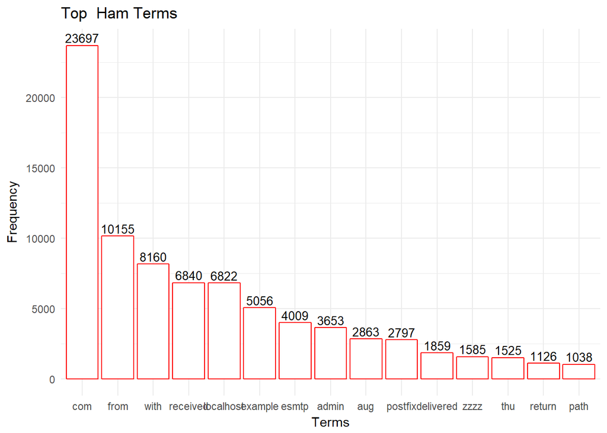

```r
ggplot(head(ham_df,15), aes(x= reorder(Terms, -Frequency), y= Frequency)) +
  geom_bar(stat="identity", color="red", fill="white") +
  geom_text(aes(label=Frequency), vjust=-0.3, size=3.5)+
  theme_minimal()+ labs(title="Top  Ham Terms")+
  labs( x='Terms')
```

```r
word_frequency_spam <- rowSums(as.matrix(spam_tdm_new))
word_frequency_spam
```

```
##          aug        linux    localhost          org spamassassin
##         1163          839         2638         3084         1134
##        taint         zzzz     received        esmtp          ist
##         1210         2158         2495         1115          738
##          com      message      content         text         type
##         5139          801         1569         1124         1284
##      subject         list         http          www         free
##          771          840         2919         1560          789
##         mail          net         name         will         html
##         1207         2077          996          850         1092
##        align      bgcolor       border       center       height
##         1901          837         1372         1580         1716
##        table        width          gif         href          img
##         1522         3118          749          916         1066
##          src         nbsp        arial        color         face
##         1041         1631         1295         2270         2327
##         font         size      verdana        value       option
##         9266         3294          934         1103         1099
##        style          sep
##         1008         2129
```

Comprehensive dataframe spam_tdm_new

```r
spam_df <- as.data.frame(as.table(spam_tdm_new))%>%
  mutate(Indentifier = "spam")%>%
  filter(Freq > 0)%>%
  rename(Frequency = Freq)%>%
  select(-(Docs))%>%
  group_by(Terms,Indentifier ) %>%
  summarise(Frequency = sum(Frequency))

knitr::kable(spam_df,  caption = "Spam Frequency Table")
```

Spam Frequency Table

| Terms | Indentifier | Frequency |
| --- | --- | --- |
| aug | spam | 1163 |
| linux | spam | 839 |
| localhost | spam | 2638 |
| org | spam | 3084 |
| spamassassin | spam | 1134 |
| taint | spam | 1210 |
| zzzz | spam | 2158 |
| received | spam | 2495 |
| esmtp | spam | 1115 |
| ist | spam | 738 |
| com | spam | 5139 |
| message | spam | 801 |
| content | spam | 1569 |
| text | spam | 1124 |
| type | spam | 1284 |
| subject | spam | 771 |
| list | spam | 840 |
| http | spam | 2919 |
| www | spam | 1560 |
| free | spam | 789 |
| mail | spam | 1207 |
| net | spam | 2077 |
| name | spam | 996 |
| will | spam | 850 |
| html | spam | 1092 |
| align | spam | 1901 |
| bgcolor | spam | 837 |
| border | spam | 1372 |
| center | spam | 1580 |
| height | spam | 1716 |
| table | spam | 1522 |
| width | spam | 3118 |
| gif | spam | 749 |
| href | spam | 916 |
| img | spam | 1066 |
| src | spam | 1041 |
| nbsp | spam | 1631 |
| arial | spam | 1295 |
| color | spam | 2270 |
| face | spam | 2327 |
| font | spam | 9266 |
| size | spam | 3294 |
| verdana | spam | 934 |
| value | spam | 1103 |
| option | spam | 1099 |
| style | spam | 1008 |
| sep | spam | 2129 |

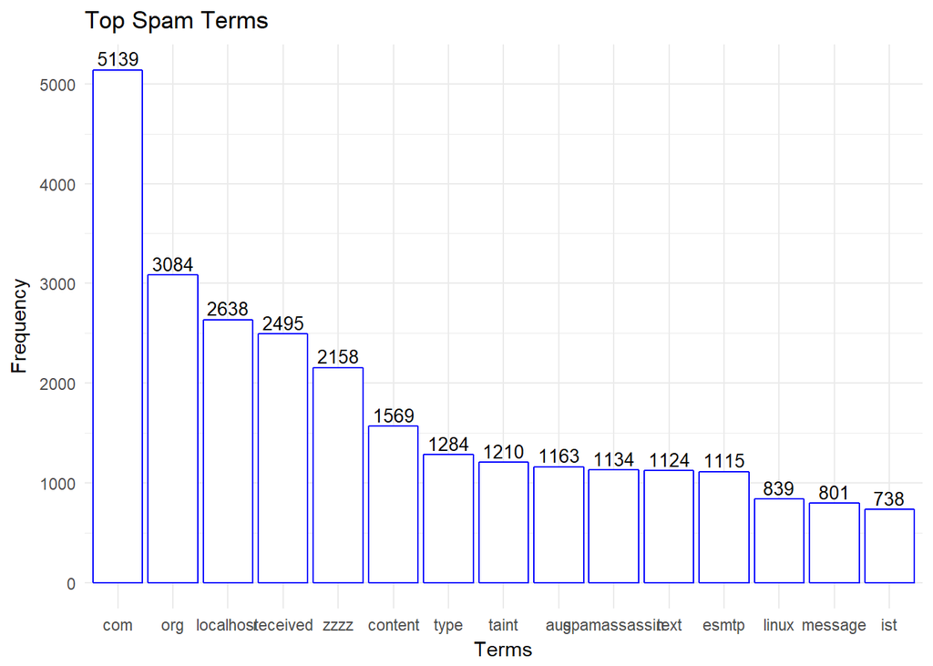

```r
ggplot(head(spam_df,15), aes(x= reorder(Terms, -Frequency), y= Frequency)) +
  geom_bar(stat="identity", color="blue", fill="white") +
  geom_text(aes(label=Frequency), vjust=-0.3, size=3.5)+
  theme_minimal()+ labs(title="Top Spam Terms")+
  labs( x='Terms')
```

Merge the Spam and Ham Data Frames:

```r
# join the ham and spam dataframes into one
comprehensive_df <- merge(x = ham_df, y = spam_df, by="Terms", all = TRUE)

comprehensive_df <-comprehensive_df %>%
  replace_na(list(Frequency.x = 0, Frequency.y = 0,
                  Indentifier.x = "ham", Indentifier.y = "spam"))%>%
  rename(ham_identifier = Indentifier.x, spam_identifier = Indentifier.y,
         ham_frequency = Frequency.x, spam_frequency =Frequency.y)%>%
  mutate(total = ham_frequency + spam_frequency,
         spam_wgt = spam_frequency/total,
         ham_wgt = 1 - spam_wgt)%>%
  arrange(desc(spam_wgt))

comprehensive_df$importance_spam = comprehensive_df$spam_frequency/sum(comprehensive_df$spam_frequency)
comprehensive_df$importance_ham = comprehensive_df$ham_frequency/sum(comprehensive_df$ham_frequency)


knitr::kable(head(comprehensive_df,15),  caption = "Combined Table")
```

Combined Table

| Terms | ham_identifier | ham_frequency | spam_identifier | spam_frequency | total | spam_wgt | ham_wgt | importance_spam | importance_ham |
| --- | --- | --- | --- | --- | --- | --- | --- | --- | --- |
| spamassassin | ham | 0 | spam | 1134 | 1134 | 1 | 0 | 0.0138688 | 0 |
| taint | ham | 0 | spam | 1210 | 1210 | 1 | 0 | 0.0147983 | 0 |
| free | ham | 0 | spam | 789 | 789 | 1 | 0 | 0.0096495 | 0 |
| mail | ham | 0 | spam | 1207 | 1207 | 1 | 0 | 0.0147616 | 0 |
| name | ham | 0 | spam | 996 | 996 | 1 | 0 | 0.0121811 | 0 |
| will | ham | 0 | spam | 850 | 850 | 1 | 0 | 0.0103955 | 0 |
| html | ham | 0 | spam | 1092 | 1092 | 1 | 0 | 0.0133552 | 0 |
| align | ham | 0 | spam | 1901 | 1901 | 1 | 0 | 0.0232493 | 0 |
| bgcolor | ham | 0 | spam | 837 | 837 | 1 | 0 | 0.0102365 | 0 |
| border | ham | 0 | spam | 1372 | 1372 | 1 | 0 | 0.0167796 | 0 |
| center | ham | 0 | spam | 1580 | 1580 | 1 | 0 | 0.0193234 | 0 |
| height | ham | 0 | spam | 1716 | 1716 | 1 | 0 | 0.0209867 | 0 |
| table | ham | 0 | spam | 1522 | 1522 | 1 | 0 | 0.0186141 | 0 |
| width | ham | 0 | spam | 3118 | 3118 | 1 | 0 | 0.0381332 | 0 |
| gif | ham | 0 | spam | 749 | 749 | 1 | 0 | 0.0091603 | 0 |

Calculate the spam and ham scores:

– read in the testing files – filter the combined dataset for the words presented in the test file – calculate the weighted scores for ham and spam – determine if it is a spam or ham file – the order of the scores (weighted ham, weighted spam and total) – the lower the total, the more “spam” like – (I tried to do a more robust train/test model but it not working)

```r
scores <- function(file){
  content <- readLines(file)
  content  <- paste(content, collapse = ' ')
  word_list <- strsplit(content , "\\W+")
  word_list <- as.data.frame(word_list)
  colnames(word_list) <- c("word")
  word_list$word <- tolower(word_list$word)

  total_score <- comprehensive_df %>%
  filter(Terms %in% as.list(word_list$word))

  ham_score <- (sum(total_score$ham_frequency *total_score$importance_ham ))

  print(paste0("ham score: ",ham_score))

  spam_score<- (sum(total_score$spam_frequency * total_score$importance_spam))

  print(paste0("spam score: ",spam_score))


  total <- ham_score - spam_score
  print(paste0("total score: ",total))
}
```

Test a few of the ham files: – All the ham files are above a 5000 weighted score

```r
scores("C:/Data 607/Project 4/ham/0004.e8d5727378ddde5c3be181df593f1712")
```

```
## [1] "ham score: 6251.74837672242"
## [1] "spam score: 989.925176723822"
## [1] "total score: 5261.8231999986"
```

```r
scores("C:/Data 607/Project 4/ham/0015.a9ff8d7550759f6ab62cc200bdf156e7")
```

```
## [1] "ham score: 6073.83725825148"
## [1] "spam score: 1004.28478829831"
## [1] "total score: 5069.55246995317"
```

```r
scores("C:/Data 607/Project 4/ham/0039.5bf1ec6602c4657bac8d566604572ad5")
```

```
## [1] "ham score: 6087.55857308453"
## [1] "spam score: 803.196096176895"
## [1] "total score: 5284.36247690764"
```

```r
scores("C:/Data 607/Project 4/ham/0040.930593a7e616570a2b63f2d774847316")
```

```
## [1] "ham score: 6110.66488142448"
## [1] "spam score: 737.474488173568"
## [1] "total score: 5373.19039325091"
```

```r
scores("C:/Data 607/Project 4/ham/0090.314ec4268af7a3a1974d5eab84ea65af")
```

```
## [1] "ham score: 6401.4392393038"
## [1] "spam score: 1036.37837242864"
## [1] "total score: 5365.06086687516"
```

Test a few of the spam files: – All the spam files are below a 5000 weighted score

```r
scores("C:/Data 607/Project 4/spam/00002.d94f1b97e48ed3b553b3508d116e6a09")
```

```
## [1] "ham score: 5736.62277207875"
## [1] "spam score: 969.204094611452"
## [1] "total score: 4767.4186774673"
```

```r
scores("C:/Data 607/Project 4/spam/00016.67fb281761ca1051a22ec3f21917e7c0")
```

```
## [1] "ham score: 5638.8805921368"
## [1] "spam score: 862.218342587384"
## [1] "total score: 4776.66224954942"
```

```r
scores("C:/Data 607/Project 4/spam/00037.21cc985cc36d931916863aed24de8c27")
```

```
## [1] "ham score: 5629.44815098878"
## [1] "spam score: 2416.78842061493"
## [1] "total score: 3212.65973037386"
```

```r
scores("C:/Data 607/Project 4/spam/00103.2eef38789b4ecce796e7e8dbe718e3d2")
```

```
## [1] "ham score: 5875.5201983667"
## [1] "spam score: 965.450260499474"
## [1] "total score: 4910.06993786723"
```

```r
scores("C:/Data 607/Project 4/spam/00146.e9b64856c0cd982a64f47c9ab9084287")
```

```
## [1] "ham score: 5970.00891168498"
## [1] "spam score: 2655.81916689088"
## [1] "total score: 3314.1897447941"
```